# 第11回 dplyrとデータ加工

プログラミング演習Ⅰ

佐藤 秀保

sato0035@toyo.jp

## 先週までの内容

- **エクセルデータ読込**
  - Filesペイン→Upload
  - Environmentペイン→Import Dataset
- **パッケージのインストールと読込**
  - ダブルクォーテーションの有無に注意
  - インストールは一回すればOK

```r
#tidyverseパッケージの例
#先週やっていない方はやること
install.packages("tidyverse")
library(tidyverse)
```

## 準備

1. [Posit Cloud](https://posit.cloud/)へ（日本語訳しないことを推奨）
2. 作成済みのプロジェクトをクリック
3. 先週使用のスクリプトをすべて閉じる
4. 新しくスクリプトを作成
5. 作成したスクリプトを保存：名前は「lecture11」
6. ほうきボタンでオブジェクトを削除

授業中のコードはすべてスクリプトに書き実行すること

## データ読込

- ACEにアップロードしたエクセルファイル**「syokudo_data2」を各自読み込むこと**
  - 朝霞キャンパス食堂の日別売上データ（2025年6月1～20日）

## select関数

- 列の抽出

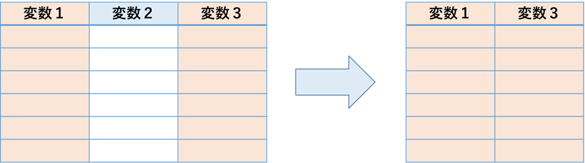

**文法：select(データフレーム名, 列名１, 列名2, …)**

- syokudo_data2から「日付」，「総売上」の列を抽出
- df1という名前に保存

```r
df1 <- select(syokudo_data2, 日付, 総売上)
```

## filter関数

- 行の抽出

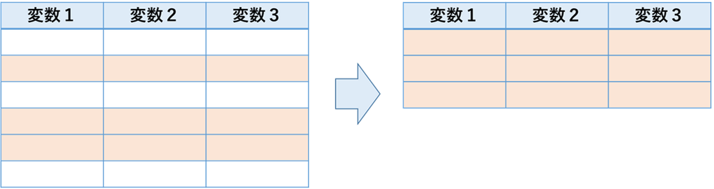

**文法：filter(データフレーム名, 条件式１, 条件式2, …)**

- syokudo_data2から「総売上」> 0に該当する行を抽出
- df2という名前に保存

```r
df2 <- filter(syokudo_data2, 総売上 > 0)
```

- syokudo_data2から「総売上」 >0 かつ「客数」 >= 400に該当する行を抽出
- df3という名前に保存

```r
#コンマの後などで改行すると見やすい場合あり
df3 <- filter(syokudo_data2,
              総売上 > 0,
              客数 >= 400)
```

## mutate関数

- 列の追加

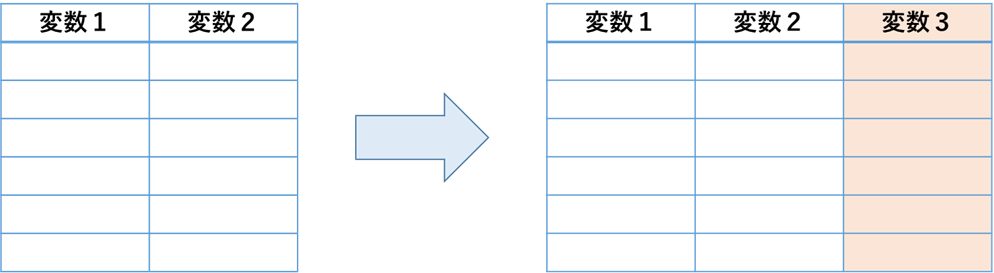

**文法：mutate(データフレーム名, 新しい列名1 = 計算式, 新しい列名2 = 計算式, …)**

- syokudo_data2から「総売上」÷「客数」を行った結果を新しい列「客単価」として追加
- df4という名前に保存

```r
df4 <- mutate(syokudo_data2, 客単価 = 総売上 / 客数)
```

- syokudo_data2の「日付」から対応する曜日を検索し，新しい列「曜日」として追加
  - weekdays(日付)という関数・引数で計算可
- df5という名前に保存

```r
df5 <- mutate(syokudo_data2, 曜日 = weekdays(日付))
```

## arrange関数

- 行の並び替え

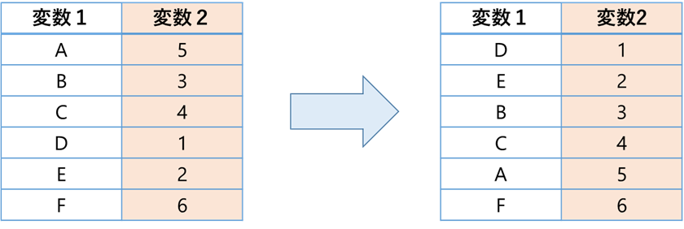

**文法：arrange(データフレーム名, 昇順に並び替えする変数)**

- syokudo_data2を「総売上」の昇順に並び替え
- df6という名前に保存

```r
df6 <- arrange(syokudo_data2, 総売上)
```

**文法：arrange(データフレーム名, desc(降順に並べ替えする変数)**)

- syokudo_data2を「総売上」の降順**desc**endingに並び替え
- df7という名前に保存

```r
df7 <- arrange(syokudo_data2, desc(総売上))
```

## rename関数

- 列名の変更

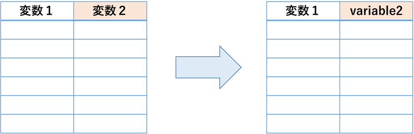

**文法：rename(データフレーム名, 新しい列名1 = 古い列名1, 新しい列名2 = 古い列名2, …)**

- syokudo_data2の「日付」を「date」に変更
- df8という名前に保存

```r
df8 <- rename(syokudo_data2, date = 日付)
```

## summarise関数

- 記述統計量を計算しデータフレームに保存

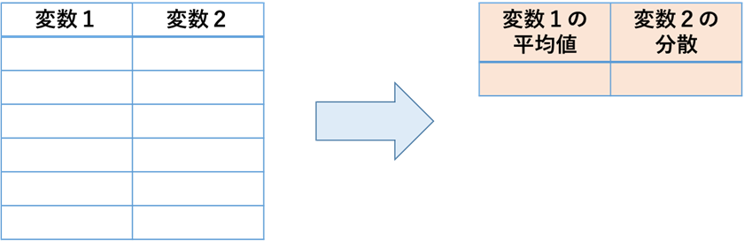

**文法：summarise(データフレーム名, 新しい列名1 = 記述統計計算の関数(計算する列名1), 新しい列名2 = 記述統計計算の関数(計算する列名2), …)**

- syokudo_data2の「総売上」の平均値と「客数」の分散を計算
  - NAの行は削除しないと計算できないので先にfilterをかけておく
- df9という名前に保存

```r
df_filter <- filter(syokudo_data2, 総売上 > 0, 客数 > 0)
df9 <- summarise(df_filter,
                 総売上の平均 = mean(総売上),
                 客数の分散 = var(客数))
```

## 演習

syokudo_data2のデータを用いて，「客数」の月曜日の平均値と「客数」の火曜日の平均値をそれぞれアトミックベクトルとして抽出し，その値を比較せよ．

- ヒント
  1. filterで「客数」のNAを削除
  2. mutateで「曜日」の列を追加
  3. filterで「月曜日」を抽出
  4. summariseで平均を計算したデータフレームをゲット
  5. 4をアトミックベクトルとして抽出

※火曜日も上の方法と同様

ただし，3で月曜日をfilterするときは，filter(データフレーム名, 曜日 == “月曜日”)のように==を使うことでその曜日に等しい場合の行を抽出できることに注意する．

## 課題

- ACEの小テスト：「第11回」
- ACEのレポート：「第11回」
  - ローカルに保存したlecture11.Rを提出